# Aula 8 - Introdução à Econometria

João Ricardo F. de Lima

03 de maio de 2022.

# 1 Quebra de Pressupostos do Modelo Clássico de Regressão Linear

## 1.1 Multicolinearidade

Uma das premissas do Modelo Clássico de Regressão Linear é que não existe **multicolinearidade** entre as variáveis explicativas no modelo de regressão a ser estimado. Originalmente, **multicolinearidade** designava a existência de uma “relação perfeita” entre algumas ou todas as variáveis explicativas de um modelo de regressão. Atualmente, também é considerado o caso de **multicolinearidade** menos que perfeita.

```r
x1 <- c(10,15,18,24,30)
x2 <- c(50,75,90,120,150)
x3 <- c(52,75,97,129,152)
x <- cbind(x1,x2,x3)
cor(x)
```

```
##           x1        x2        x3
## x1 1.0000000 1.0000000 0.9958817
## x2 1.0000000 1.0000000 0.9958817
## x3 0.9958817 0.9958817 1.0000000
```

A correlação entre $X_1$ e $X_2$ é igual a 1. A correlação entre $X_1$ e $X_3$ é 0,995. No primeiro caso se tem perfeita correlação. Se fosse estimar um modelo de regressão com estas duas variáveis explicativas, $X_1$ e $X_2$, teriamos um caso de multicolinearidade perfeita e os betas não seriam estimáveis. A demonstração é dada em Gujarati & Porter (2009).

A título de exemplo, se pode observar com a matrix X abaixo:

$$\mathbf{X}=\left[\begin{array}{ccc}
1 & 10 & 50 \\
1 & 15 & 75 \\
1 & 18 & 90 \\
\end{array} \right];
\mathbf{X'X}=\left[\begin{array}{ccc}
3 & 43 &
215 \\
43 & 649
& 3245 \\
215 & 3245
& 16225 \\
\end{array}
\right]$$

sendo o determinante desta matriz igual a zero $|\mathbf{X'X}|=0$.

```r
x1 <- c(1,1,1)
x2 <- c(10,15,18)
x3 <- c(50,75,90)
x <- cbind(x1,x2,x3)

x <- as.matrix(x)

# X'X
m1 <- t(x) %*% x

m1
```

```
##     x1   x2    x3
## x1   3   43   215
## x2  43  649  3245
## x3 215 3245 16225
```

```r
# Determinante

det(m1)
```

```
## [1] 0
```

A colinearidade se refere às relações lineares entre as variáveis explicativas. Não inclui relações não lineares, como por exemplo:

$$Y_i=\beta_0+\beta_1X+\beta_2X^2+\beta_3X^3$$

em que Y é o custo total e X a quantidade produzida

## 1.2 Consequências da multicolinearidade

Os estimadores de MQO continuam não viesados e eficientes (possuem variância mínima).

Contudo, esta variância é “inflada”, ou seja, muito grande.

Se o erro padrão é grande, os intervalos de confiança também serão mais amplos:

$$IC=\hat\beta\pm t_{\alpha/2}ep(\hat \beta)$$

Como o erro padrão é grande, normalmente os betas são não significativos, ou seja, iguais a zero.

O $R^2$ tende a ser muito alto.

Os estimadores de MQO e os erros-padrões podem ser sensíveis às pequenas mudanças nos dados.

Em resumo, os resultados encontrados se tornam duvidosos quando se regride com regressores colineares.

## 1.3 Como detectar a multicolinearidade?

Na regressão, encontrar muitos betas estimados não significativos e o $R^2$ muito alto.

Altos valores de correlações entre pares de regressores;

Calcular regressões auxiliares. Dado o modelo:

$$Y_i=\beta_0+\beta_1X_1+\beta_2X_2+\beta_3X_3+u$$

calcular o $R^2$ e chamar de $R^2$ geral. Depois regredir:

$$X_1=\beta_0+\beta_2X_2+\beta_3X_3+u$$

$$X_2=\beta_0+\beta_1X_1+\beta_3X_3+u$$

$$X_3=\beta_0+\beta_1X_1+\beta_2X_2+u$$

calcular em cada regressão auxiliar os $R^2$: a) $R^2_{x_2.x_3x_4}$; b) $R^2_{x_3.x_2x_4}$; c) $R^2_{x_4.x_2x_3}$

comparar cada um com o $R^2$ geral. Pela *Regra Prática de Klein*, a multicolinearidade é um problema sério se o $R^2$ obtido em todas as regressões auxiliares for maior que o $R^2$ geral.

**Fator de Inflação de Variância** - Considerando uma regressão múltipla com duas variáveis explicativas, as variâncias dos coeficientes de inclinação são dadas por:

$$Var(\hat\beta_2)=\frac{\sigma^2}{\sum x^2_2(1-r^2_{23})}$$

$$Var(\hat\beta_3)=\frac{\sigma^2}{\sum x^2_3(1-r^2_{23})}$$

em que $\sigma^2$ é a variância do termo de erro e $r^2_{23}$ é o coeficiente de correlação entre $x_2$ e $x_3$.

se considerarmos a razão $\frac{1}{1-r^2_{23}}$, esta mensura o grau na qual a variância do estimador de MQO é inflado devido a colinearidade. Este fator é conhecido como **FIV** (Fator de Inflação de Variância).

Se o FIV for maior do que 10 diz-se que esta variável é altamente colinear; Com mais de 2 variáveis, o quadrado do coeficiente de correlação pode ser obtido do $R^2$ das regressões auxiliares.

## 1.4 Medidas corretivas para Multicolinearidade

1. Aumentar o tamanho da amostra;
2. Exclusão de variáveis, desde que não cause viés de especificação ou omissão de variável relevante.

## 1.5 Multicolinearidade: Exemplo no R

### 1.5.1 Estimação do Modelo

```r
#Direcionando o R para o Diretorio a ser trabalhado
setwd('C:/Users/Joao Ricardo Lima/Dropbox/tempecon/facape/econometria1')

#Inicio do Script
#Pacotes a serem utilizados
library(foreign)
library(car)
library(corrplot)
library(HH)

#Lendo os dados no R de um arquivo do Stata
wage1 <- read.dta("wage1.dta")
attach(wage1)

#Regressao Multipla
#tenure= anos no emprego atual
regressao1 <- lm(log(wage) ~ educ + exper + tenure)
summary(regressao1)
```

```
##
## Call:
## lm(formula = log(wage) ~ educ + exper + tenure)
##
## Residuals:
##      Min       1Q   Median       3Q      Max
## -2.05802 -0.29645 -0.03265  0.28788  1.42809
##
## Coefficients:
##             Estimate Std. Error t value Pr(>|t|)
## (Intercept) 0.284360   0.104190   2.729  0.00656 **
## educ        0.092029   0.007330  12.555  < 2e-16 ***
## exper       0.004121   0.001723   2.391  0.01714 *
## tenure      0.022067   0.003094   7.133 3.29e-12 ***
## ---
## Signif. codes:  0 '***' 0.001 '**' 0.01 '*' 0.05 '.' 0.1 ' ' 1
##
## Residual standard error: 0.4409 on 522 degrees of freedom
## Multiple R-squared:  0.316,  Adjusted R-squared:  0.3121
## F-statistic: 80.39 on 3 and 522 DF,  p-value: < 2.2e-16
```

### 1.5.2 Início da análise: verificação da correlação

```r
#Matriz de Correlacoes das variaveis explicativas
x <- wage1[, c(2,3,4)]
cor(x)
```

```
##               educ      exper      tenure
## educ    1.00000000 -0.2995418 -0.05617257
## exper  -0.29954184  1.0000000  0.49929145
## tenure -0.05617257  0.4992914  1.00000000
```

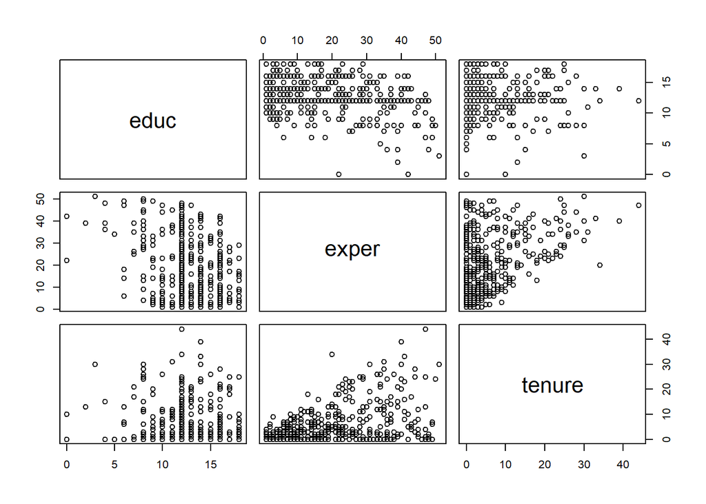

```r
pairs(x)
```

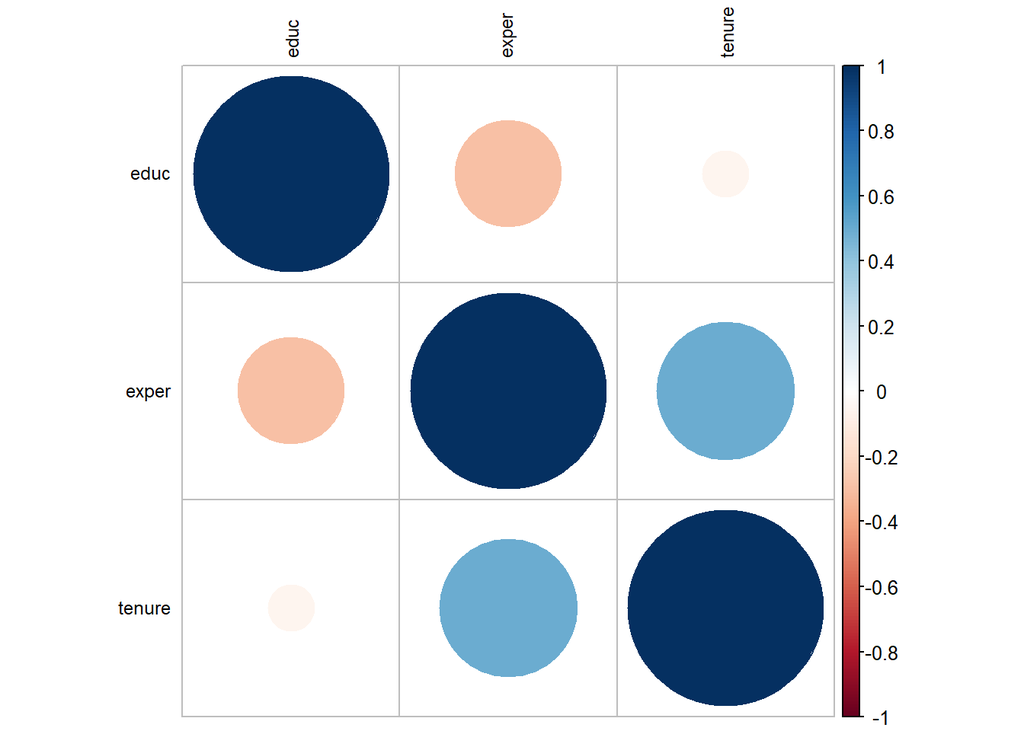

```r
corrplot(cor(x), order="hclust", tl.col="black", tl.cex = .75)
```

### 1.5.3 Estimação das regressões auxiliares

```r
#Regressoes Auxiliares

aux1 <- lm(educ ~ exper + tenure)
summary(aux1)
```

```
##
## Call:
## lm(formula = educ ~ exper + tenure)
##
## Residuals:
##      Min       1Q   Median       3Q      Max
## -12.4285  -1.3536  -0.2055   1.6550   5.9791
##
## Coefficients:
##              Estimate Std. Error t value Pr(>|t|)
## (Intercept) 13.574964   0.184324  73.647  < 2e-16 ***
## exper       -0.073785   0.009761  -7.559 1.83e-13 ***
## tenure       0.047680   0.018337   2.600  0.00958 **
## ---
## Signif. codes:  0 '***' 0.001 '**' 0.01 '*' 0.05 '.' 0.1 ' ' 1
##
## Residual standard error: 2.63 on 523 degrees of freedom
## Multiple R-squared:  0.1013, Adjusted R-squared:  0.09791
## F-statistic: 29.49 on 2 and 523 DF,  p-value: 7.327e-13
```

```r
aux2 <- lm(exper~ educ + tenure)
summary(aux2)
```

```
##
## Call:
## lm(formula = exper ~ educ + tenure)
##
## Residuals:
##     Min      1Q  Median      3Q     Max
## -24.041  -8.484  -2.999   6.078  34.299
##
## Coefficients:
##             Estimate Std. Error t value Pr(>|t|)
## (Intercept) 29.14613    2.31629  12.583  < 2e-16 ***
## educ        -1.33493    0.17659  -7.559 1.83e-13 ***
## tenure       0.90925    0.06769  13.433  < 2e-16 ***
## ---
## Signif. codes:  0 '***' 0.001 '**' 0.01 '*' 0.05 '.' 0.1 ' ' 1
##
## Residual standard error: 11.19 on 523 degrees of freedom
## Multiple R-squared:  0.3232, Adjusted R-squared:  0.3206
## F-statistic: 124.9 on 2 and 523 DF,  p-value: < 2.2e-16
```

```r
aux3 <- lm(tenure ~ educ + exper)
summary(aux3)
```

```
##
## Call:
## lm(formula = tenure ~ educ + exper)
##
## Residuals:
##      Min       1Q   Median       3Q      Max
## -13.1743  -3.4190  -0.7172   1.7178  30.5870
##
## Coefficients:
##             Estimate Std. Error t value Pr(>|t|)
## (Intercept)  -3.0591     1.4666  -2.086  0.03748 *
## educ          0.2677     0.1029   2.600  0.00958 **
## exper         0.2821     0.0210  13.433  < 2e-16 ***
## ---
## Signif. codes:  0 '***' 0.001 '**' 0.01 '*' 0.05 '.' 0.1 ' ' 1
##
## Residual standard error: 6.231 on 523 degrees of freedom
## Multiple R-squared:  0.2589, Adjusted R-squared:  0.256
## F-statistic: 91.34 on 2 and 523 DF,  p-value: < 2.2e-16
```

### 1.5.4 Cálculo do Fator de Inflação da Variância

```r
#Fator de Inflacao da Variancia (FIV)
vif(regressao1)
```

```
##     educ    exper   tenure
## 1.112771 1.477618 1.349296
```

### 1.5.5 Uso do pacote {performance}

```r
pacman::p_load(
"performance",
"lme4",
"see",
"qqplotr"
)

model_performance(regressao1)
```

[output not shown]

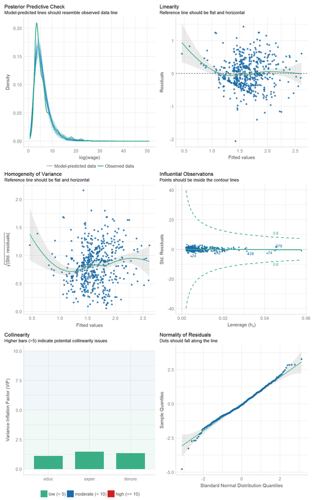

```r
check_model(regressao1)
```